# IODS course project

Ashwini Joshi

21 November, 2021

# Introduction to Open Data Science - Course Project

# About the project

This is ‘Open data science’ course. I am familiar with R and R studio. I have used Git earlier but I am not confident enough to use it independently. I am interested in learning about data science and how Statistics can be conveyed to non-statisticians. I was searching for a course not necessarily in Statistics but a course that will talk about data science applicable for any field and some simple ways of learning and using Github. The reviews of earlier students of this course encouraged me to enroll in this course. My github repository for this course: https://github.com/Ashwini-Helsinki/IODS-project

# Regression and model validation

First thing is to load required libraries or R packages for this exercise.

```r
# Required libraries
library(GGally)
library(ggplot2)
```

## Read the data

The data created in data wrangling exercise is read as ‘data2’ here. The data is about 166 students. Each row describes one student with 7 columns of information. Information such as age, gender, student’s learning approaches (such as deep learning, surface learning and strategic learning) and attitude towards Statistics is given in various columns of the data. Column ‘Points’ gives exam points of each student.

```r
setwd("D:/Helsinki/Courses/OpenDataScience/IODS-project/")
data2 <- read.csv("data/learning2014.csv",header = TRUE)

# Dimension of data: rows and columns respectively.
dim(data2)
```

```
## [1] 166   7
```

```r
# Stucture of data
str(data2)
```

```
## 'data.frame':    166 obs. of  7 variables:
##  $ gender  : chr  "F" "M" "F" "M" ...
##  $ Age     : int  53 55 49 53 49 38 50 37 37 42 ...
##  $ attitude: num  3.7 3.1 2.5 3.5 3.7 3.8 3.5 2.9 3.8 2.1 ...
##  $ deep    : num  3.58 2.92 3.5 3.5 3.67 ...
##  $ stra    : num  3.38 2.75 3.62 3.12 3.62 ...
##  $ surf    : num  2.58 3.17 2.25 2.25 2.83 ...
##  $ Points  : int  25 12 24 10 22 21 21 31 24 26 ...
```

## Graphical overview

Summary of each variable in the analysis data is shown below. For each variable its minimum value, maximum value, 1st, 2nd (median) and 3rd quantile and mean value is shown in the summary.

```r
summary(data2)
```

```
##     gender               Age           attitude          deep
##  Length:166         Min.   :17.00   Min.   :1.400   Min.   :1.583
##  Class :character   1st Qu.:21.00   1st Qu.:2.600   1st Qu.:3.333
##  Mode  :character   Median :22.00   Median :3.200   Median :3.667
##                     Mean   :25.51   Mean   :3.143   Mean   :3.680
##                     3rd Qu.:27.00   3rd Qu.:3.700   3rd Qu.:4.083
##                     Max.   :55.00   Max.   :5.000   Max.   :4.917
##       stra            surf           Points
##  Min.   :1.250   Min.   :1.583   Min.   : 7.00
##  1st Qu.:2.625   1st Qu.:2.417   1st Qu.:19.00
##  Median :3.188   Median :2.833   Median :23.00
##  Mean   :3.121   Mean   :2.787   Mean   :22.72
##  3rd Qu.:3.625   3rd Qu.:3.167   3rd Qu.:27.75
##  Max.   :5.000   Max.   :4.333   Max.   :33.00
```

Let’s examine in detail how each of the variable in the data is distributed and the relationship of these variables with each other.

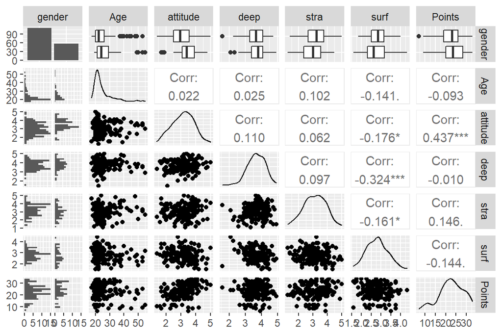

```r
# create graphical overview of variables with ggpairs()
p <- ggpairs(data2, mapping = aes(), lower = list(combo = wrap("facethist", bins = 20)))

# draw the plot
p
```

Above graph shows distribution of each variable in the data and its correlation with other variables in the data. This is a plot matrix with 7 rows and 7 columns. Each row and each column represents one variable from the data.

For all other variables except ‘gender’, density plot is shown in the diagonal position. In all other positions of the same column below the diagonal entry, a scatter plot of joint observations with the variable in the corresponding row are shown. Similarly, in the same row on the right side of the diagonal position shows correlation between the row and column variables.

Since gender variable has only 2 values ‘F’ and ‘M’, above plot has shown histogram for gender variable. Also, its relation with other variables is also shown by histograms (in the first column) and box plots (in the first row) of those variables in each gender.

From the correlations, it can be seen that attitude towards Statistics and exam points are positively correlated. It means better the attitude more the exam points. Surface learning is negatively correlated with all other variables.

How these variables are different for two ‘gender’ groups is shown in the following graph. Transparency of the overlapping plots is set by alpha.

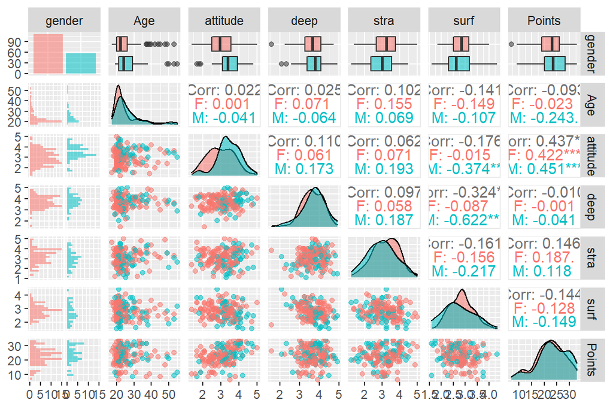

```r
# create graphical overview of variables with ggpairs()
p1 <- ggpairs(data2, mapping = aes(col= gender, alpha = 0.3), lower = list(combo = wrap("facethist", bins = 20)))

# draw the plot
p1
```

## Linear regression

Let’s fit a linear regression model to study effect of three covariates attitude, deep and stra on exam points.

```r
my_model1 <- lm(Points ~ attitude + deep + stra, data= data2)

summary(my_model1)
```

```
##
## Call:
## lm(formula = Points ~ attitude + deep + stra, data = data2)
##
## Residuals:
##      Min       1Q   Median       3Q      Max
## -17.5239  -3.4276   0.5474   3.8220  11.5112
##
## Coefficients:
##             Estimate Std. Error t value Pr(>|t|)
## (Intercept)  11.3915     3.4077   3.343  0.00103 **
## attitude      3.5254     0.5683   6.203 4.44e-09 ***
## deep         -0.7492     0.7507  -0.998  0.31974
## stra          0.9621     0.5367   1.793  0.07489 .
## ---
## Signif. codes:  0 '***' 0.001 '**' 0.01 '*' 0.05 '.' 0.1 ' ' 1
##
## Residual standard error: 5.289 on 162 degrees of freedom
## Multiple R-squared:  0.2097, Adjusted R-squared:  0.195
## F-statistic: 14.33 on 3 and 162 DF,  p-value: 2.521e-08
```

The ‘t value’ in the summary table shows test statistic for the statistical test of parameter (coefficient) corresponding to each covariate (explanatory variable). It tests if the coefficient is zero or not. If the coefficient is away from zero that means the corresponding explanatory variable has impact on the response (target) variable. If the standardize test statistic (t value) is large ( positive or negative) then the corresponding p-value is small; indicating statistical significance of the covariate.

Summary of the model shows that ‘attitude’ and ‘stra’ have statistically significant relationship with the target variable ‘Points’ since the p-values corresponding to them are small. p-value corresponding to co-variate ‘attitude’ is less than 0.001. The estimate of its coefficient is 3.5254 with standard error 0.5683. Increase of 1 unit in attitude increases the exam points by 3.5254 units.

p-value corresponding to ‘stra’ is less than 0.1. It has coefficient estimate of 0.9621 indicating 0.9621 units increase in exam points when ‘stra’ is increased by 1 unit.

Variable ‘deep’ is not showing significant relationship with ‘Points’ (p-value > 0.3) hence, it is removed from the model.

The intercept term has a large estimate of 11.3915. The p-value corresponding to intercept is also very small indicating that some important covariates are not considered in the model.

However, no new covariate will be added at this stage. As per the instructions in the exercise, we will fit the new model by removing ‘deep’.

```r
my_model2 <- lm(Points ~ attitude + stra , data= data2)

summary(my_model2)
```

```
##
## Call:
## lm(formula = Points ~ attitude + stra, data = data2)
##
## Residuals:
##      Min       1Q   Median       3Q      Max
## -17.6436  -3.3113   0.5575   3.7928  10.9295
##
## Coefficients:
##             Estimate Std. Error t value Pr(>|t|)
## (Intercept)   8.9729     2.3959   3.745  0.00025 ***
## attitude      3.4658     0.5652   6.132 6.31e-09 ***
## stra          0.9137     0.5345   1.709  0.08927 .
## ---
## Signif. codes:  0 '***' 0.001 '**' 0.01 '*' 0.05 '.' 0.1 ' ' 1
##
## Residual standard error: 5.289 on 163 degrees of freedom
## Multiple R-squared:  0.2048, Adjusted R-squared:  0.1951
## F-statistic: 20.99 on 2 and 163 DF,  p-value: 7.734e-09
```

Summary of the new model is shown above. Relationship of attitude and ‘stra’ has not changed much as compared to the previous model. The model can be written as

Points = 8.9729 + (3.4658 * attitude) + (0.9137 * stra) + (Error term)

Error term is considered to be normally distributed. Multiple R-squared is 0.2048. It means this model does not explain variation in the response variable ‘Points’ well.

To study model fitting in more detail, let’s examine various plots of the models.

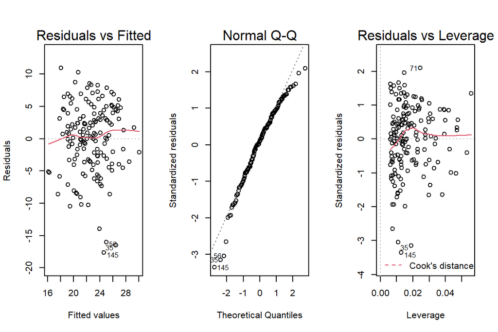

```r
par(mfrow = c(1,3))
plot(my_model2, which=c(1,2,5))
```

Residual vs Fitted plot is a scatter plot and no specific relation can be obtained which will indicate possible relation of the fitted value with the residual. Also, the red line is a bit deviated from the horizontal line but the deviation is not large enough. Hence, it can be observed that size of the error does not depend on the explanatory variables as assumed in linear regression.

Second assumption in linear regression is that error term is normally distributed. Second plot ’Normal Q-Q plot shows that most of the observations are close to the straight line. But some observations (number 35, 56,145) and some observations at the top deviate a bit from the straight line. Points in the middle region follow the assumption of normality of error term.

# Logistic Regression

First thing is to load required libraries or R packages for this exercise.

```r
# Required libraries
library(dplyr)
library(boot)
```

## Read the data

The data created in data wrangling exercise is read as ‘data3’ here. This data discusses student achievement in secondary education of two Portuguese schools. The data attributes include student grades, demographic, social and school related features) and it was collected by using school reports and questionnaires. The dataset includes the performance in two distinct subjects: Mathematics (mat) and Portuguese language (por). G1, G2 and G3 show average grades earned by the student. ‘.math’ and ‘.por’ suffixes show grades in Maths and Portuguese language courses. G3 is the final year grade (issued at the 3rd period), while G1 and G2 correspond to the 1st and 2nd period grades.

```r
setwd("D:/Helsinki/Courses/OpenDataScience/IODS-project/")
data3 <- read.csv("data/Alcdata.csv",header = TRUE)

# Dimension of data: rows and columns respectively.
dim(data3)
```

```
## [1] 370  47
```

```r
# variable names of data
colnames(data3)
```

```
##  [1] "school"        "sex"           "age"           "address"
##  [5] "famsize"       "Pstatus"       "Medu"          "Fedu"
##  [9] "Mjob"          "Fjob"          "reason"        "guardian"
## [13] "traveltime"    "studytime"     "failures.math" "schoolsup"
## [17] "famsup"        "paid.math"     "activities"    "nursery"
## [21] "higher"        "internet"      "romantic"      "famrel"
## [25] "freetime"      "goout"         "Dalc"          "Walc"
## [29] "health"        "absences.math" "G1.math"       "G2.math"
## [33] "G3.math"       "failures.por"  "paid.por"      "absences.por"
## [37] "G1.por"        "G2.por"        "G3.por"        "failures"
## [41] "paid"          "absences"      "G1"            "G2"
## [45] "G3"            "alc_use"       "high_use"
```

This data is used in this analysis to study the relationships between high/low alcohol consumption and some of the other variables in the data.

## Hypothesis

Let’s choose four variables namely ‘sex’, ‘famrel’, ‘absences’ and ‘failures’. My hypotheses about relationships of these variables with high alcohol consumption are as follows:  
1. ‘sex’ may not have direct relationship with high alcohol consumption.  
2. ‘famrel’ i.e. Good family relationship has negative impact on high alcohol consumption. This is a categorical variable. Better the family relations less alcohol consumption.  
3. ‘absences’ and ‘failures’ have positive impact on high alcohol consumption. More the absences more alcohol consumption.

## Numerical and graphical exploration

Let’s observe the relationship of these 4 variables with high alcohol consumption.

1. ‘sex’ is a binary variable and ‘alcohol consumption’ is also a binary variable. So let’s use a 2x2 table and bar graph to look at their relationship.

```r
# 2x2table
table(data3$sex, data3$high_use)
```

```
##
##     FALSE TRUE
##   F   154   41
##   M   105   70
```

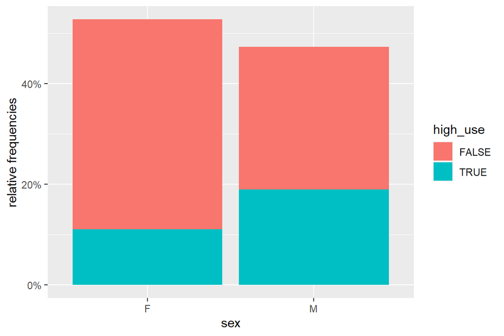

```r
# bar graph
ggplot(data3, aes(x=sex, fill=high_use))+ geom_bar(aes(y = (..count..)/sum(..count..)))+
          scale_y_continuous(labels=scales::percent) +
  ylab("relative frequencies")
```

Both the tabular view and graph show that sex ‘M’ has more percentage of high alcohol consumption than female group ‘F’. It shows that my hypothesis about relationship of ‘sex’ and ‘high/low alcohol consumption’ is not true.

2. Family relationship

Let’s look at the tabular and graphical representation.

```r
# tabular representation
table(data3$famrel, data3$high_use)
```

```
##
##     FALSE TRUE
##   1     6    2
##   2     9    9
##   3    39   25
##   4   128   52
##   5    77   23
```

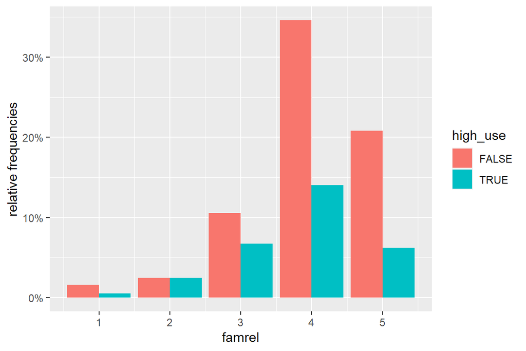

```r
# bar graph
ggplot(data3, aes(x=famrel, fill=high_use))+ geom_bar(aes(y = (..count..)/sum(..count..)), position=position_dodge())+
          scale_y_continuous(labels=scales::percent) +
  ylab("relative frequencies")
```

Both the tabular and graph show that for famrel 1 to 3 categories, relative frequency of high alcohol consumption is substantial. However, in category 4 and 5 which indicates better family relationships, has lower percentage of students with high alcohol consumption. Here my hypothesis is somewhat true.

3. Absences

```r
# tabular representation
table(data3$absences , data3$high_use)
```

```
##
##      FALSE TRUE
##   0     50   13
##   1     37   13
##   2     40   16
##   3     31    7
##   4     24   11
##   5     16    6
##   6     16    5
##   7      9    3
##   8     14    6
##   9      5    6
##   10     5    2
##   11     2    3
##   12     3    4
##   13     1    1
##   14     1    6
##   16     0    1
##   17     0    1
##   18     1    1
##   19     0    1
##   20     2    0
##   21     1    1
##   26     0    1
##   27     0    1
##   29     0    1
##   44     0    1
##   45     1    0
```

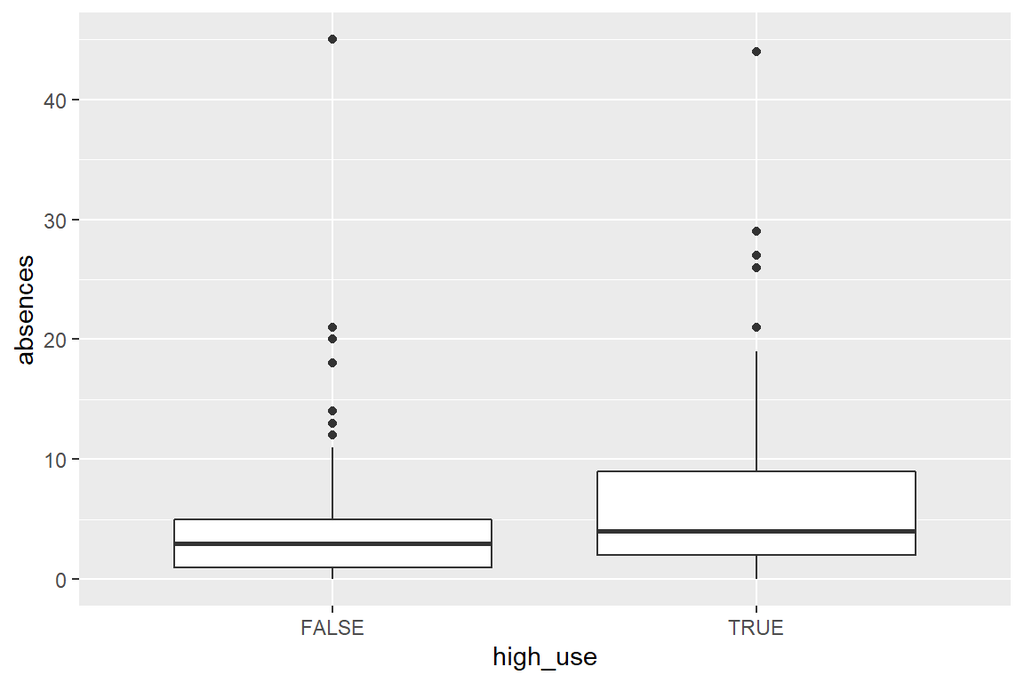

```r
# box plot
ggplot(data3, aes(x=high_use , y=absences))+ geom_boxplot()
```

Looking at the box plot, it can be seen that students with high alcohol consumption have more absences. The range in both the boxes is similar but the box with whisker in ‘True’ category is much larger and its box has 3rd quantile much above the median. It indicates that absences and high alcohol consumption are positively correlated. My hypothesis is true to an extent.

4. Failures

```r
# tabular representation
table(data3$failures , data3$high_use)
```

```
##
##     FALSE TRUE
##   0   238   87
##   1    12   12
##   2     8    9
##   3     1    3
```

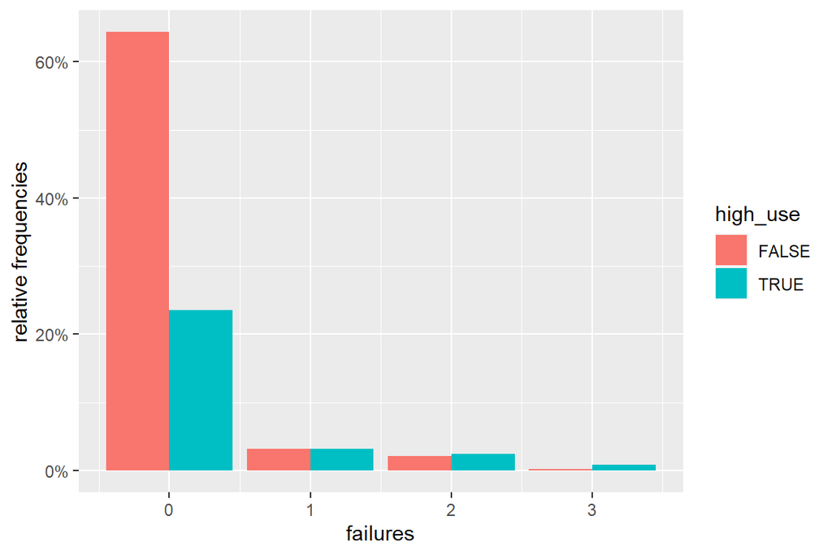

```r
# bar graph
ggplot(data3, aes(x=failures , fill=high_use))+ geom_bar(aes(y = (..count..)/sum(..count..)),position=position_dodge())+
          scale_y_continuous(labels=scales::percent) +
  ylab("relative frequencies")
```

Here high alcohol consumption increases with more number of failures. My hypothesis is true.

## Logistic regression model

Let’s fit a logistic regression model to study effect of these 4 covariates sex, famrel, absences and failures on high/low alcohol consumption. Though famrel and failures can be looked as categorical variables, the data is not equally distributed over all categories so considering any one of the category as base is difficult. Let’s continue with these variables as continuous variable. ‘Sex’ is a binary variable so one of the categories will be treated as base category and other one will be treated in comparison to the base category.

```r
# Fit logistic regression
my_model1 <- glm(high_use ~ sex +  famrel + absences + failures  , data= data3, family =binomial(link = "logit"))


# summary of the model
summary(my_model1)
```

```
##
## Call:
## glm(formula = high_use ~ sex + famrel + absences + failures,
##     family = binomial(link = "logit"), data = data3)
##
## Deviance Residuals:
##     Min       1Q   Median       3Q      Max
## -2.0786  -0.8216  -0.5746   0.9760   2.1820
##
## Coefficients:
##             Estimate Std. Error z value Pr(>|z|)
## (Intercept) -0.79406    0.54281  -1.463  0.14350
## sexM         1.04800    0.25091   4.177 2.96e-05 ***
## famrel      -0.29791    0.13044  -2.284  0.02238 *
## absences     0.08941    0.02274   3.932 8.43e-05 ***
## failures     0.57328    0.20531   2.792  0.00523 **
## ---
## Signif. codes:  0 '***' 0.001 '**' 0.01 '*' 0.05 '.' 0.1 ' ' 1
##
## (Dispersion parameter for binomial family taken to be 1)
##
##     Null deviance: 452.04  on 369  degrees of freedom
## Residual deviance: 401.77  on 365  degrees of freedom
## AIC: 411.77
##
## Number of Fisher Scoring iterations: 4
```

```r
# Estimate and confidence interval
cbind(coef(my_model1), confint(my_model1))
```

```
##                               2.5 %      97.5 %
## (Intercept) -0.79406437 -1.87558320  0.26100198
## sexM         1.04800182  0.56283743  1.54857812
## famrel      -0.29791173 -0.55591186 -0.04251048
## absences     0.08940969  0.04695413  0.13651044
## failures     0.57327802  0.17701334  0.98884313
```

‘sexM’ estimate gives coefficient of category ‘M’ when the base category ‘F’ is given by intercept term. All 4 covariates have p-value smaller than 0.05 so all 4 covariates show statistical significant relation with high alcohol consumption. Also, all the coefficients are away from zero and the 95% confidence interval exclude zero for all 4 covariates. To view these effects in terms of odds ratio, let’s take exponential of coefficients and confidence interval.

```r
# Odds ratios by exponentiating coefficients of the model
print("Odds ratios - estimate and confidence interval")
```

```
## [1] "Odds ratios - estimate and confidence interval"
```

```r
cbind(exp(coef(my_model1)), exp(confint(my_model1)))
```

```
##                           2.5 %    97.5 %
## (Intercept) 0.4520039 0.1532656 1.2982302
## sexM        2.8519467 1.7556470 4.7047758
## famrel      0.7423669 0.5735490 0.9583804
## absences    1.0935286 1.0480739 1.1462668
## failures    1.7740730 1.1936470 2.6881229
```

Although, ‘absences’ has odds ratio 1.0935286 which is not far away from 1, its confidence interval excludes zero. Hence for all 4 Odds ratio, confidence intervals exclude 1 indicating statistical relation with the target variable high_use. If this result is compared with initial hypotheses. sexM has effect on high_use hence the initial hypotheses is not true. ‘famrel’ have negative effect on high_use since the odds ratio and 95% interval lie below 1. ‘absences’ has positive impact on high_use. ‘Failures’ clearly has relation with high_use. So for these 3 covariates initial hypothesis is true.

AIC of this model is 411.77. Only when AIC of other model is known it can be compared with this AIC to decide a better model. Model with lower AIC is considered as better fit model.

## Prediction

Next step is prediction using the model my_model1. predict() function will give probabilities as the prediction for each row in the dataset. The probabilities greater than 0.5 will be considered as ‘TRUE’ (high_use = TRUE or 1) value of prediction and others as ‘FALSE’ (high_use = FALSE or 0)

```r
# predict() the probability of high_use
probabilities <- predict(my_model1, type = "response")

# add the predicted probabilities to the data to get a nwe dataset 'alc'
alc <- mutate(data3, probability = probabilities)

# use the probabilities to make a prediction of high_use
alc <- mutate(alc, prediction = probability > 0.5)
```

Next table and graph shows prediction accuracy in terms of observed value of high_use and predictions.

```r
# tabulate the target variable versus the predictions
table(high_use = alc$high_use, prediction = alc$prediction)
```

```
##         prediction
## high_use FALSE TRUE
##    FALSE   244   15
##    TRUE     77   34
```

```r
print("In terms of proportions and with margins")
```

```
## [1] "In terms of proportions and with margins"
```

```r
# tabulate the target variable versus the predictions
table(high_use = alc$high_use, prediction = alc$prediction) %>% prop.table %>% addmargins
```

```
##         prediction
## high_use      FALSE       TRUE        Sum
##    FALSE 0.65945946 0.04054054 0.70000000
##    TRUE  0.20810811 0.09189189 0.30000000
##    Sum   0.86756757 0.13243243 1.00000000
```

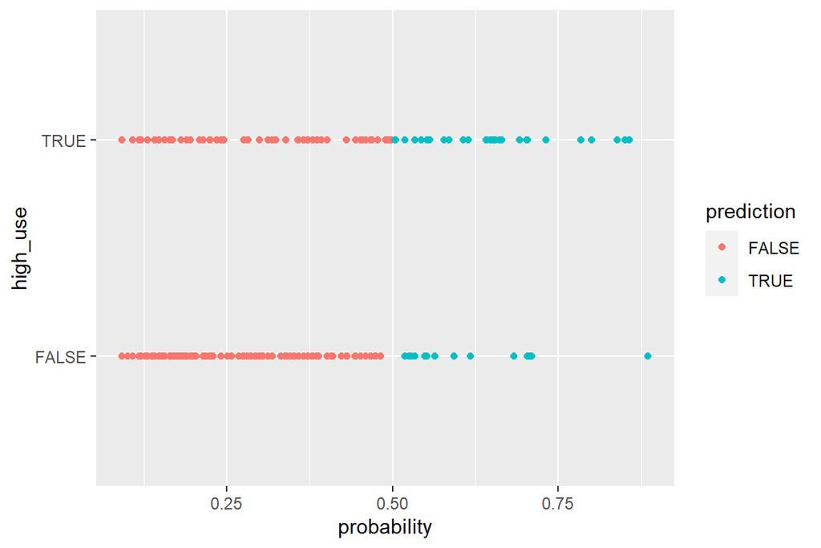

```r
# initialize a plot of 'high_use' versus 'probability' in 'alc'
g <- ggplot(alc, aes(x = probability, y = high_use, col = prediction))

# define the geom as points and draw the plot
g + geom_point()
```

To compute prediction error in terms of average number of wrong predictions, let’s define a loss function as given in the DataCamp.

```r
# define a loss function (average prediction error)
loss_func <- function(class, prob) {
  n_wrong <- abs(class - prob) > 0.5
  mean(n_wrong)
}

# call loss_func to compute the average number of wrong predictions in the (training) data
loss_func(class = alc$high_use, prob = alc$probability)
```

```
## [1] 0.2486486
```

Average number of wrong predictions with the model my_model1 are 0.24 (aprox).

## Cross validation

Let’s perform 10-fold cross validation for ‘alc’ data, model my_model1 and the loss function defined above.

```r
# K-fold cross-validation

cv <- cv.glm(data = alc, cost = loss_func, glmfit = my_model1, K = 10)

# average number of wrong predictions in the cross validation
cv$delta[1]
```

```
## [1] 0.2648649
```

With 10 fold cross validation, the average number of wrong predictions is near 0.26 (aprox.) ( The exact value is not mentioned here, since the initial seed is not set here, so each run of cv function gives slightly different value. But all of them are close to 0.26) which is more than the training error 0.24. This is expected since the training error is computed for prediction of observations used for training the model while CV error is obtained from the prediction of the observations which are not used for training the model. Training error can be viewed as error given by only estimation error. The uncertainty due to new unknown data is not there. Hence, CV error is always greater than the training error.

Looking at the cv error, one can claim that performance of this model is similar to that of the model given in DataCamp.

Next, let’s consider large number of predictors to start with and keep reducing 1 predictor in each step based on their deviance. In each step one covariate, which contributes to the error the most, is removed from the model. The process continues till no further improvement is achieved by removing a covariate. This can be performed using ‘step’ function on the full model.

```r
# formula using 26 covariates in the data is created.
BiggerFormula <- as.formula(high_use ~sex + age+famsize+Pstatus+Medu+Fedu+Mjob+
  Fjob+guardian+traveltime+studytime+schoolsup+famsup+activities+nursery+higher+
  internet+romantic+famrel+freetime+goout+health+failures+paid+absences+G3)

# glm is fitted to the bigger formula.
FullModel <- glm(BiggerFormula,family=binomial(link="logit"),data=data3)

# For loop to reduce 1 covariate in every step.
finalDF <- c() # to save final result
numcov = 26 # initial number of covariates

for( mm in 1:26){

  prevnumcov= numcov

  # perform stepwise backward elimination with steps = mm
  Newmodel <- step(FullModel,direction="backward",trace=FALSE, steps =mm)

  numcov=length(coef(Newmodel))-1

  if(numcov == prevnumcov){
    print(paste0("No further improvement after ",prevnumcov, " variables." ))
    break
  }
  # predict() the probability of high_use
  probabilities <- predict(Newmodel, type = "response")

  # add the predicted probabilities to the data to get a nwe dataset 'alc'
  alc1 <- mutate(alc, probability1 = probabilities)

  # use the probabilities to make a prediction of high_use
  alc1 <- mutate(alc1, prediction1 = probability1 > 0.5)

  trainerror = loss_func(class = alc1$high_use, prob = alc1$probability1)

  cv <- cv.glm(data = alc1, cost = loss_func, glmfit = Newmodel, K = 10)

  # average number of wrong predictions in the cross validation
  newcv = cv$delta[1]
  finalDF <- rbind(finalDF, c(numcov,trainerror,'Training'),c(numcov,newcv,'Prediction'))
}
```

```
## [1] "No further improvement after 9 variables."
```

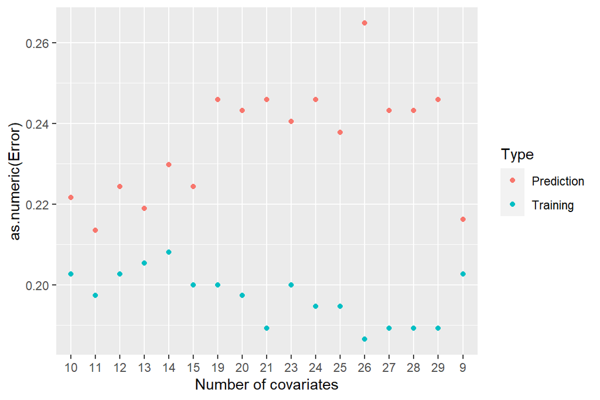

```r
finalDF = data.frame(finalDF)
colnames(finalDF) <- c('Number of covariates', 'Error', 'Type')

ggplot(finalDF, aes(x= `Number of covariates`, y=as.numeric(Error), col=Type)) +
  geom_point() + scale_y_continuous(labels = scales::number_format(accuracy = 0.01))
```

For models with large number of covariates, training error is smaller but prediction error is large. Models with properly chosen less number of covariates have training error not largely different but much lesser prediction error.